# Data Quality - Case

## Problem

GrowBetter has created a novel greenhouse for growing rice. Currently, they have a lot of data on rice_yield, temperature, fertilizer, and water. They also used to keep track of whether or not an individual was a largeholder farmer or a smallholder farmer, but stopped because they did not find it useful.

A year later, the government is now introducing rewards for working with smallholder farmers, who have historically been hit very hard by climate change. GrowBetter would now like to find a way to classify the farmers they currently serve and have provided you an old dataset of when they used to keep track of farmer data to do this.

They already have an an analyst on their team, however this analyst is split across many data projects right now and would like you to prepare the data for analysis.

## Step 1: Import Modules and Read CSV

```python
import numpy as np
import pandas as pd
import scipy as sp
from imblearn.over_sampling import SMOTE
import matplotlib.pyplot as plt
%matplotlib inline
```

```python
df = pd.read_csv("data/RiceProduction.csv", index_col = 0)
```

```python
df.shape # rows, cols
```

```
(2199, 5)
```

```python
df.head()
```

|  | rice_yield | temperature | fertilizer | water | farmer_type |
| --- | --- | --- | --- | --- | --- |
| 0 | 0.94 | 4.44 | 0.016 | 9.09 | small |
| 1 | 0.91 | 11.40 | 0.102 | 9.38 | large |
| 2 | 0.20 | 18.60 | 0.054 | 8.01 | small |
| 3 | 0.56 | 18.03 | 0.085 | 7.06 | small |
| 4 | 0.81 | 35.95 | 0.111 | 3.49 | small |

## Step 2: Summary Statistics

```python
df.describe()
```

|  | rice_yield | temperature | fertilizer | water |
| --- | --- | --- | --- | --- |
| count | 2186.000000 | 2195.000000 | 2187.000000 | 2199.000000 |
| mean | 0.511874 | 10.214510 | 0.081328 | 5.267376 |
| std | 0.300613 | 16.802683 | 0.040809 | 2.883883 |
| min | -1.000000 | -20.000000 | 0.001000 | 0.000000 |
| 25% | 0.280000 | 1.670000 | 0.049000 | 2.960000 |
| 50% | 0.510000 | 10.280000 | 0.081000 | 5.440000 |
| 75% | 0.770000 | 19.075000 | 0.108000 | 7.710000 |
| max | 1.030000 | 200.000000 | 0.195000 | 9.990000 |

**Analyze Results**

- The maximum for temperature seems way too high (actually impossibly high)
- The minimum rice yield is negative -- how can this be possible?

Let's see if these are outliers.

## Step 3: Visualize

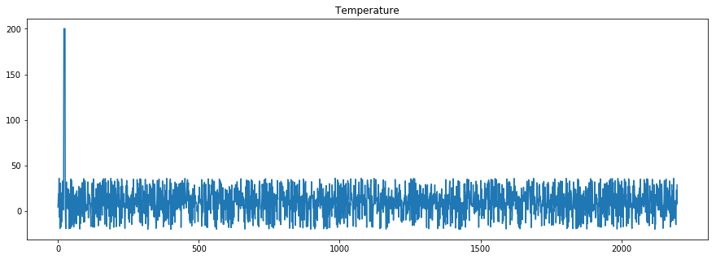

```python
plt.figure(figsize=(15,5)) # set x and y lengths
plt.title('Temperature')
plt.plot(df["temperature"])
```

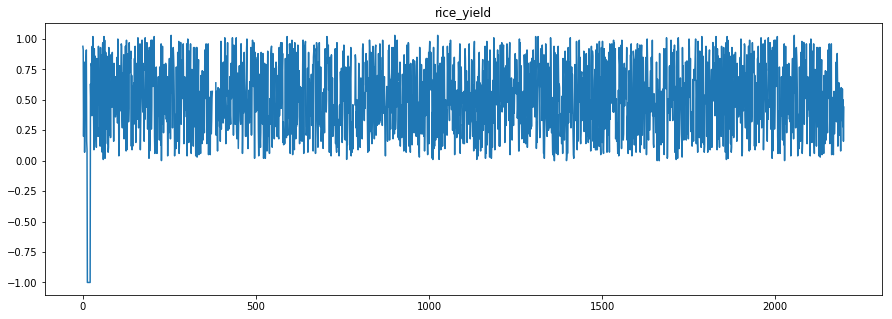

```python
plt.figure(figsize=(15,5))
plt.title('rice_yield')
plt.plot(df["rice_yield"])
```

Yes, these are outliers.

Should we remove?

- Given the visualizations and it does not make sense where these data points come from (they appear physically infeasible), we can remove these outliers.

## Step 4: Remove Outliers

```python
df = df.drop(df[df['temperature'] == 200].index)
```

```python
df = df.drop(df[df['rice_yield'] == -1].index)
```

```python
df.describe()
```

|  | rice_yield | temperature | fertilizer | water |
| --- | --- | --- | --- | --- |
| count | 2173.000000 | 2182.000000 | 2174.000000 | 2186.000000 |
| mean | 0.517840 | 9.790825 | 0.081319 | 5.269382 |
| std | 0.285178 | 14.163040 | 0.040836 | 2.881467 |
| min | 0.000000 | -20.000000 | 0.001000 | 0.000000 |
| 25% | 0.280000 | 1.692500 | 0.049000 | 2.970000 |
| 50% | 0.510000 | 10.270000 | 0.081000 | 5.430000 |
| 75% | 0.770000 | 19.032500 | 0.108000 | 7.707500 |
| max | 1.030000 | 35.970000 | 0.195000 | 9.990000 |

This makes more sense now. Let's keep digging.

## Step 5: Check for Duplicates

```python
# df.duplicated([columns]) creates a list which rows have duplicates
# So, this really becomes df[Select rows with duplicates]
# The length of this is how many duplicates there are
len(df[df.duplicated(['rice_yield', 'temperature','fertilizer', 'water', 'farmer_type'])])
```

```
368
```

We have 368 duplicates.

## Step 6: Drop Duplicates

```python
df.shape # before dropping
```

```
(2186, 5)
```

```python
df = df.drop_duplicates(subset = ['rice_yield', 'temperature','fertilizer', 'water', 'farmer_type'])
```

```python
df.shape # after dropping
```

```
(1818, 5)
```

## Step 7: Check for Missing Values

```python
df.isnull().values.any()  # this checks if any value is NULL
```

```
True
```

This means we do have missing values.

In this case, let's drop rows with missing values.

## Step 8: Drop Missing Values

```python
df.shape # gets the (rows, cols) of a dataframe
```

```
(1818, 5)
```

```python
df = df.dropna(axis = 0) # axis 0 is the default and drops rows, if we set axis to 1 it drops columns
```

```python
df.shape
```

```
(1781, 5)
```

## Step 9: Check for Class Imbalance in Farmers

```python
df['farmer_type'].value_counts() # counts how much of each class in a column exists
```

```
large    1210
small     563
lage        8
Name: farmer_type, dtype: int64
```

**Analyze Results**

- There does seem to be a class imbalance between large and small farmers
- There seems to be a typo where large was inputted in as "lage"
  - Let's correct that quickly

## Step 10: Fix Class Values

```python
df['farmer_type'] = df['farmer_type'].replace('lage','large') # replaces all values that say "lage" with "large"
```

```python
df['farmer_type'].value_counts()
```

```
large    1218
small     563
Name: farmer_type, dtype: int64
```

Upon asking the client about this balance, they state that the majority of rice farmers are largeholder farms and that these numbers make sense.

- So, this class balance represents the reality
- In order to prepare the data for analysis, we will need to balance the classes

## Step 11: Balance Farmer Type Class with SMOTE

```python
X = df.loc[:, df.columns != 'farmer_type'] # .loc lets us access rows and columns by labels
X.head()
```

|  | rice_yield | temperature | fertilizer | water |
| --- | --- | --- | --- | --- |
| 0 | 0.94 | 4.44 | 0.016 | 9.09 |
| 1 | 0.91 | 11.40 | 0.102 | 9.38 |
| 2 | 0.20 | 18.60 | 0.054 | 8.01 |
| 3 | 0.56 | 18.03 | 0.085 | 7.06 |
| 4 | 0.81 | 35.95 | 0.111 | 3.49 |

```python
y = df['farmer_type']
y.head()
```

```
0    small
1    large
2    small
3    small
4    small
Name: farmer_type, dtype: object
```

```python
sm = SMOTE(random_state = 2) # create SMOTE object
X2, y2 = sm.fit_sample(X, y) # fit X onto y with SMOTE
```

Combine the results into one dataframe

```python
df_balanced = X2
df_balanced['farmer_type'] = y2
df_balanced.head()
```

|  | rice_yield | temperature | fertilizer | water | farmer_type |
| --- | --- | --- | --- | --- | --- |
| 0 | 0.94 | 4.44 | 0.016 | 9.09 | small |
| 1 | 0.91 | 11.40 | 0.102 | 9.38 | large |
| 2 | 0.20 | 18.60 | 0.054 | 8.01 | small |
| 3 | 0.56 | 18.03 | 0.085 | 7.06 | small |
| 4 | 0.81 | 35.95 | 0.111 | 3.49 | small |

```python
df_balanced['farmer_type'].value_counts()
```

```
small    1218
large    1218
Name: farmer_type, dtype: int64
```

Now our classes are balanced!

## Step 12: Plot Distributions of Features

[output not shown]

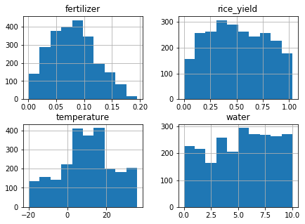

```python
df_balanced.hist(figsize = (7,5))
```

```python
df_balanced.describe()
```

|  | rice_yield | temperature | fertilizer | water |
| --- | --- | --- | --- | --- |
| count | 2436.000000 | 2436.000000 | 2436.000000 | 2436.000000 |
| mean | 0.510291 | 9.979789 | 0.080333 | 5.284094 |
| std | 0.272758 | 13.788124 | 0.040072 | 2.853190 |
| min | 0.000000 | -20.000000 | 0.001000 | 0.000000 |
| 25% | 0.285302 | 2.062616 | 0.049000 | 3.000113 |
| 50% | 0.491281 | 10.420000 | 0.079000 | 5.535000 |
| 75% | 0.740383 | 18.991325 | 0.107000 | 7.680000 |
| max | 1.030000 | 35.970000 | 0.195000 | 9.990000 |

**Analyze Results**

- Fertilizer and temperature seem to follow Gaussian distributions
- Cannot tell distributions rice_yield and water follow, rice_yield might loosely follow a Gaussian distribution
- Looking at the summary statistics again, fertilizer is on a much lower scale than temperature, rice_yield, and water

## Step 14: Standardize Data

- We choose to standardize the data as the majority of the features seem to follow a Gaussian distribution and the scales of the features are not equal

```python
df_balanced.describe().columns
```

```
Index(['rice_yield', 'temperature', 'fertilizer', 'water'], dtype='object')
```

```python
for col in df_balanced.describe().columns:
    df_balanced[col] = (df_balanced[col]-df_balanced[col].mean())/(df_balanced[col].std()) # we can do operations across dataframes
```

```python
df_balanced.describe()
```

|  | rice_yield | temperature | fertilizer | water |
| --- | --- | --- | --- | --- |
| count | 2.436000e+03 | 2.436000e+03 | 2.436000e+03 | 2.436000e+03 |
| mean | -3.904056e-15 | 7.083824e-16 | 1.734610e-15 | 1.093816e-17 |
| std | 1.000000e+00 | 1.000000e+00 | 1.000000e+00 | 1.000000e+00 |
| min | -1.870855e+00 | -2.174320e+00 | -1.979778e+00 | -1.851995e+00 |
| 25% | -8.248674e-01 | -5.742024e-01 | -7.819261e-01 | -8.005011e-01 |
| 50% | -6.969379e-02 | 3.192683e-02 | -3.326856e-02 | 8.793868e-02 |
| 75% | 8.435748e-01 | 6.535723e-01 | 6.654785e-01 | 8.397288e-01 |
| max | 1.905384e+00 | 1.884971e+00 | 2.861541e+00 | 1.649349e+00 |

## Step 15: Client Deliverable

```python
df_balanced
```

|  | rice_yield | temperature | fertilizer | water | farmer_type |
| --- | --- | --- | --- | --- | --- |
| 0 | 1.575421 | -0.401780 | -1.605449 | 1.333912 | small |
| 1 | 1.465434 | 0.103002 | 0.540702 | 1.435553 | large |
| 2 | -1.137605 | 0.625191 | -0.657150 | 0.955389 | small |
| 3 | 0.182246 | 0.583851 | 0.116463 | 0.622428 | small |
| 4 | 1.098809 | 1.883520 | 0.765300 | -0.628803 | small |
| 5 | -1.614218 | -1.198843 | 0.964942 | -1.277200 | large |
| 6 | -0.364026 | 1.434583 | -1.106344 | -0.839094 | large |
| 7 | -0.367692 | -2.116299 | 0.615568 | -0.639317 | large |
| 8 | 0.882500 | 1.383090 | 0.939986 | -0.344910 | small |
| 9 | 1.065812 | 1.488253 | 0.865121 | -0.506133 | large |
| 10 | 1.465434 | -0.734675 | -0.108134 | -0.422017 | large |
| 11 | -1.284255 | -1.976323 | -0.033269 | -0.611279 | large |
| 12 | -1.540893 | 0.720200 | 0.116463 | 1.568737 | large |
| 13 | -0.514342 | -0.355363 | 0.715389 | 1.312883 | small |
| 14 | 1.575421 | -1.662285 | -0.083179 | -1.844985 | large |
| 15 | 0.292233 | -2.114123 | 1.364226 | -0.586745 | large |
| 16 | 1.868721 | -0.101521 | -1.081389 | 1.249796 | small |
| 17 | 0.039262 | 1.593416 | 0.890076 | -0.842599 | small |
| 18 | -0.551005 | -0.433691 | -0.183000 | 0.447186 | small |
| 19 | -1.540893 | 0.387305 | -1.006523 | 0.573360 | small |
| 20 | 1.502096 | -0.316924 | 0.465836 | 0.229885 | large |
| 21 | 0.108921 | 1.061073 | 0.191329 | -1.000317 | small |
| 22 | 1.282121 | -0.570040 | 0.341060 | 1.460087 | large |
| 23 | -1.210930 | 0.582401 | 0.590613 | 1.053525 | large |
| 24 | -0.551005 | -0.335781 | -0.307776 | 1.137641 | large |
| 25 | -1.137605 | 1.006679 | 1.314315 | -1.228132 | small |
| 26 | -1.467568 | 0.323482 | -0.557329 | 0.923845 | large |
| 27 | 1.208796 | -2.119925 | 0.216284 | -1.550578 | small |
| 28 | -0.807642 | 0.630268 | 0.091508 | 0.044128 | large |
| 29 | -0.917630 | 0.551214 | -0.931658 | 1.235777 | small |
| ... | ... | ... | ... | ... | ... |
| 2406 | 0.196206 | 0.695875 | 0.009022 | 0.524761 | small |
| 2407 | -1.291652 | 1.676895 | -0.402981 | -1.752601 | small |
| 2408 | 1.051477 | -0.112487 | -1.414328 | 0.611914 | small |
| 2409 | -1.223246 | -0.374828 | 0.556389 | 0.835969 | small |
| 2410 | 0.219992 | 1.879995 | 1.681391 | -1.512025 | small |
| 2411 | -0.646387 | -0.479325 | -0.963592 | -0.036764 | small |
| 2412 | 1.208796 | -1.334922 | 0.962004 | -1.207805 | small |
| 2413 | -0.917255 | 0.850796 | 0.274631 | -1.259972 | small |
| 2414 | 0.816580 | 1.085772 | 1.270515 | -0.424617 | small |
| 2415 | -0.972682 | 0.511111 | -0.343730 | 0.764273 | small |
| 2416 | 1.815765 | -0.087030 | -0.997282 | 1.337546 | small |
| 2417 | -0.335444 | 1.434624 | 0.606792 | -0.279217 | small |
| 2418 | -1.460683 | -1.474266 | 0.512156 | -1.425739 | small |
| 2419 | 0.893012 | 0.024424 | -0.295652 | 1.070487 | small |
| 2420 | -0.599584 | -0.356606 | 0.587129 | 1.309881 | small |
| 2421 | -0.567936 | -0.018347 | -1.664658 | -0.074715 | small |
| 2422 | 0.275314 | -0.138949 | -1.368821 | 0.607959 | small |
| 2423 | 1.345837 | 1.419929 | 0.859814 | -1.654399 | small |
| 2424 | 1.191695 | -0.642954 | -1.533168 | 1.450032 | small |
| 2425 | 0.806962 | -0.342533 | -0.067513 | 0.029943 | small |
| 2426 | -1.162767 | -0.555528 | 0.360607 | 0.022139 | small |
| 2427 | 0.127295 | 0.274088 | -0.319036 | 0.856886 | small |
| 2428 | -0.410672 | 0.044668 | -0.376166 | 0.368929 | small |
| 2429 | -0.787734 | 0.687895 | -0.237828 | 0.145882 | small |
| 2430 | -0.409807 | 0.614601 | 0.479474 | 0.138329 | small |
| 2431 | -0.276604 | 1.024703 | -0.242261 | -0.835425 | small |
| 2432 | 1.400908 | 0.091507 | -0.960290 | 1.340671 | small |
| 2433 | -1.169766 | -0.377758 | 0.371576 | 0.827710 | small |
| 2434 | -1.098738 | 0.212945 | -0.324866 | 1.606297 | small |
| 2435 | -0.986782 | -0.877180 | 1.117919 | -0.789114 | small |

2436 rows × 5 columns

We now have a cleaned and balanced dataset that can be used for developing predictive models on whether or not a farmer is a largeholder farmer or a smallholder farmer.

## Conclusion

In this case, we learned how to iteratively clean a dataset and prepare it for analysis. As seen, this is an extensive process. However, without this step, no proper analysis can be done!